# Advanced Static Cartography in R — Exercises with Solutions (Sessions 6–8)

2026-09-27

## Required packages

```r
library(tmap)
library(tmap.glyphs)
library(tmap.cartogram)
library(sf)
library(dplyr)
library(gridmappr)
```

> **Datasets used** — all from the `tmap` package, no downloads needed.

> | Object | Rows | Type | Key variables |
> | --- | --- | --- | --- |
> | `World` | 177 | polygon | `continent`, `pop_est`, `gdp_cap_est`, `life_exp`, `well_being`, `footprint`, `inequality`, `press` |
> | `NLD_dist` | 3340 | polygon | `code`, `name`, `population`, `income_low`, `income_high`, `edu_appl_sci` |

In this exercise set we use the districts (*wijken*) of The Hague (’s-Gravenhage, municipality code 0518), a city with large differences between neighbourhoods. The unpopulated dunes (Oostduinen) are left out.

```r
DH_dist = NLD_dist[substr(NLD_dist$code, 3, 6) == "0518" & NLD_dist$population > 0, ]
DH_dist$name = sub("^Wijk [0-9]+ ", "", DH_dist$name)   # "Wijk 29 Schildersbuurt" -> "Schildersbuurt"
DH_dist$income_middle = 100 - DH_dist$income_low - DH_dist$income_high
```

# Exercise 1 — Glyph maps (session 6)

1. Make a donut map of the income composition of the districts in `DH_dist`: `"income_low"`, `"income_middle"` and `"income_high"` as parts, and `"population"` as size.

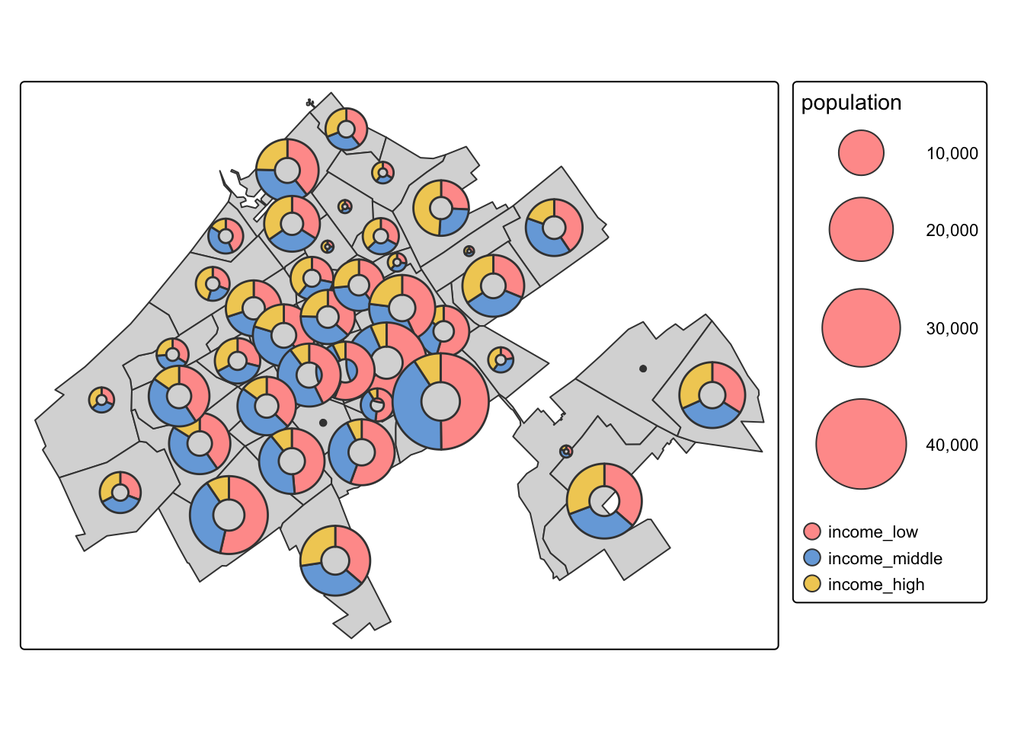

```r
income_vars = c("income_low", "income_middle", "income_high")

tm_shape(DH_dist) +
  tm_polygons() +
  tm_donuts(
    parts = tm_vars(income_vars, multivariate = TRUE),
    size = "population")
```

2. The income classes are *ordered*. Choose a palette that reflects this (e.g. a diverging palette from `c4a_gui()`, with a neutral color for the middle class), and use readable labels in the legend.

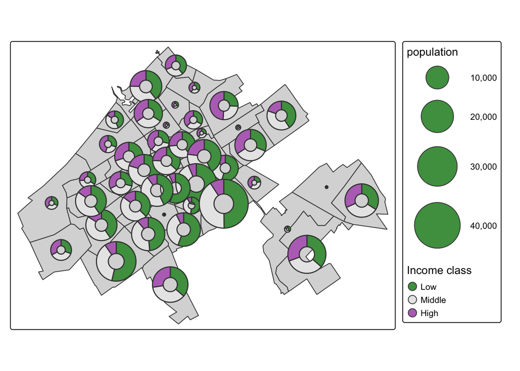

```r
tm_shape(DH_dist) +
  tm_polygons() +
  tm_donuts(
    parts = tm_vars(income_vars, multivariate = TRUE),
    fill.scale = tm_scale_categorical(values = "-pu_gn_div",
      labels = c("Low", "Middle", "High")),
    fill.legend = tm_legend("Income class"),
    size = "population")
```

> **Answer:** A categorical scale is still needed (each part is a category), but the colors can come from a diverging palette, so the order of the classes is visible and the middle class is neutral.
3. Tune the size scale (`values.scale`, `values.range`, `ticks`) so that the small donuts are still readable and the large ones do not overlap too much. Make the background map subtle. Where are the differences between districts largest?

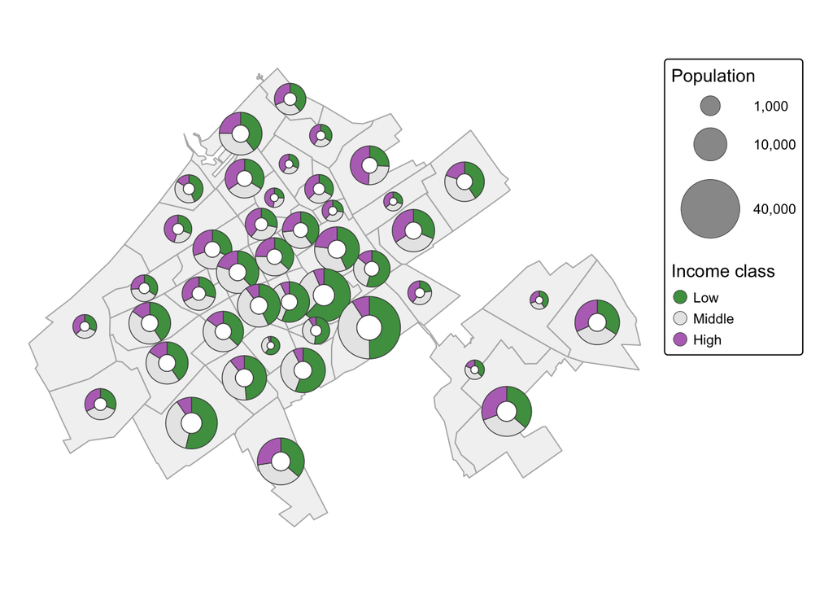

```r
tm_shape(DH_dist) +
  tm_polygons(fill = "grey95", col = "grey70") +
  tm_donuts(
    parts = tm_vars(income_vars, multivariate = TRUE),
    fill.scale = tm_scale_categorical(values = "-pu_gn_div",
      labels = c("Low", "Middle", "High"),
      value.neutral = "grey60"),
    fill.legend = tm_legend("Income class"),
    size = "population",
    size.scale = tm_scale_continuous(
      values.scale = 0.8,
      values.range = c(0.3, 1),
      ticks = c(1000, 10000, 40000)),
    size.legend = tm_legend("Population"),
    col = "grey30", lwd = 0.5,
    options = opt_tm_donuts(fill_hole = "white")) +
tm_layout(frame = FALSE)
```

> **Answer:** The districts north of the centre, towards the dunes (e.g. Benoordenhout, Vogelwijk, Zorgvliet), have many high incomes; the districts south of the centre (Schildersbuurt, Transvaalkwartier, Moerwijk) have mostly low incomes. The central districts are small and dense, so their donuts overlap.
4. Would a flower map (`tm_flowers()`) be suitable for these data? Why (not)?

> **Answer:** Not really: the income classes are parts of a whole (they add up to 100%), which is exactly what pies and donuts show. Flowers are suited to *profiles* of separate indicators on a common scale.

# Exercise 2 — Tile grid map (session 7)

1. Compute a grid layout for the districts of `DH_dist` with `gridmappr::points_to_grid()`, using their centroids. Try an 8 × 8 grid and a few values of `compactness`.

```r
cent = st_coordinates(st_centroid(st_geometry(DH_dist)))
pts = tibble(name = DH_dist$name, x = cent[, 1], y = cent[, 2])

solution = points_to_grid(pts, n_row = 8, n_col = 8, compactness = 0.6)
```

2. Convert the solution to polygons with `make_grid()`, join the district data, and make a tile grid map of the percentage of people with a university degree (`"edu_appl_sci"`). Label the tiles with the district names, broken into lines (see the `wrap()` helper in session 7). Use white labels on the dark tiles.

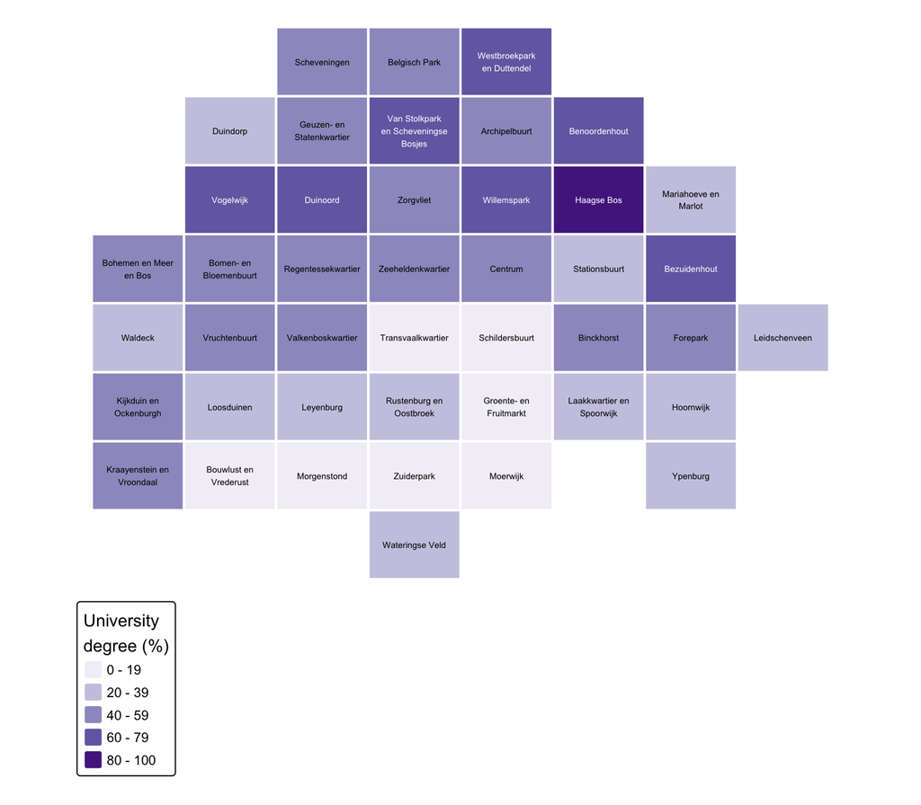

```r
DH_tiles = make_grid(DH_dist, n_row = 8, n_col = 8) |>
  inner_join(solution, by = c("row", "col")) |>
  left_join(st_drop_geometry(DH_dist), by = "name")

wrap = function(x, width) {
  x = gsub("(?<!'s)-(?=\\S)", "-~ ", x, perl = TRUE)
  x = vapply(strwrap(x, width, simplify = FALSE), paste, "", collapse = "\n")
  gsub("-~ ?", "-", x)
}
DH_tiles$label = wrap(DH_tiles$name, width = 16)

brks = c(0, 20, 40, 60, 80, 100)

tm_shape(DH_tiles) +
  tm_polygons(
    fill = "edu_appl_sci",
    fill.scale = tm_scale_intervals(breaks = brks, values = "brewer.purples"),
    fill.legend = tm_legend("University\ndegree (%)"),
    col = "white", lwd = 2) +
  tm_text("label", size = 0.45,
    col = "edu_appl_sci",
    col.scale = tm_scale_intervals(breaks = brks,
      values = c("black", "black", "black", "white", "white")),
    col.legend = tm_legend_hide()) +
tm_layout(frame = FALSE)
```

3. Put the income donuts of exercise 1 on the grid map: one donut per tile, all of the same size, with the name below each donut. Show the real map next to it, so readers can relate the tiles to the geography.

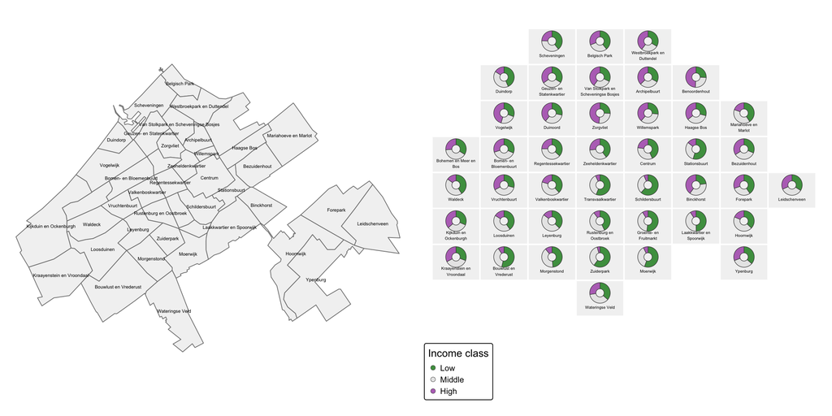

```r
DH_tiles$label2 = wrap(DH_tiles$name, width = 20)

h = diff(st_bbox(DH_tiles[1, ])[c("ymin", "ymax")])   # tile height
DH_donuts = DH_tiles
st_geometry(DH_donuts) = (st_centroid(st_geometry(DH_tiles)) + c(0, 0.15 * h)) |>
  st_set_crs(st_crs(DH_tiles))

tm_grid = tm_shape(DH_tiles) +
  tm_polygons(fill = "grey95", col = "white", lwd = 2) +
  tm_text("label2", size = 0.35, ymod = -2) +
tm_shape(DH_donuts) +
  tm_donuts(
    parts = tm_vars(income_vars, multivariate = TRUE),
    fill.scale = tm_scale_categorical(values = "-pu_gn_div",
      labels = c("Low", "Middle", "High")),
    fill.legend = tm_legend("Income class"),
    size = 0.45,
    col = "grey30", lwd = 0.5) +
  tm_layout(frame = FALSE)

tm_real = tm_shape(DH_dist) +
  tm_polygons(fill = "grey95", col = "grey50") +
  tm_text("name", size = 0.4, options = opt_tm_text(remove_overlap = TRUE)) +
  tm_layout(frame = FALSE)

tmap_arrange(tm_real, tm_grid, ncol = 2)
```

> **Discuss:** what is gained and what is lost compared to the donut map of exercise 1c?

# Exercise 3 — Cartograms (session 8)

1. Make a contiguous cartogram of South America (`World`, `continent == "South America"`) with the population (`"pop_est"`) as size, and life expectancy (`"life_exp"`) as fill color. Remember to set an equal-area CRS in `tm_shape()`.

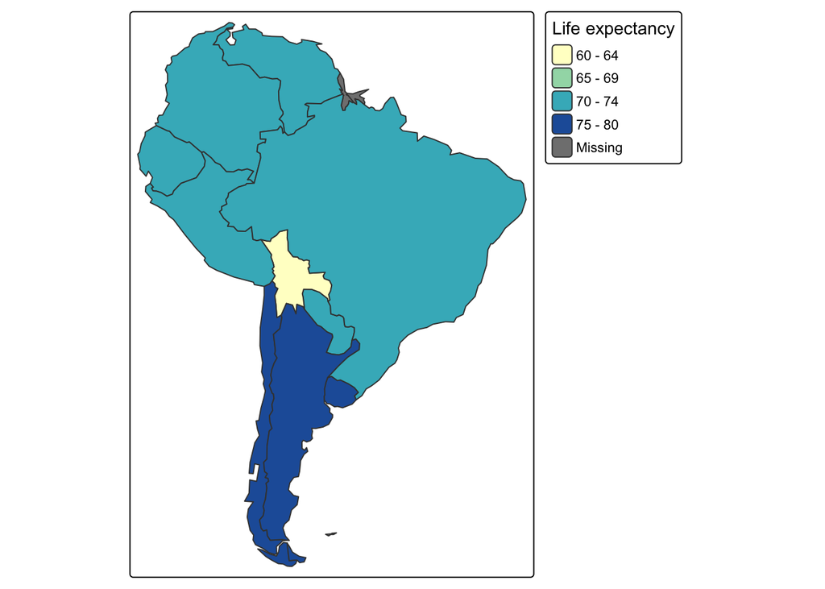

```r
SAm = World[World$continent == "South America", ]

tm_shape(SAm, crs = "auto") +
  tm_cartogram(
    size = "pop_est",
    fill = "life_exp",
    fill.scale = tm_scale_intervals(values = "brewer.yl_gn_bu"),
    fill.legend = tm_legend("Life expectancy"))
```

2. Make the same map as a non-contiguous cartogram, with the original country shapes as background. Add the country names.

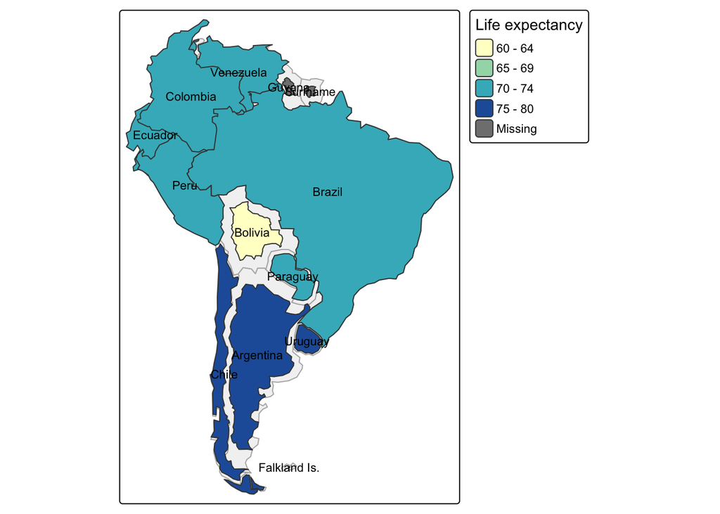

```r
tm_shape(SAm, crs = "auto") +
  tm_polygons(fill = "grey95", col = "grey70") +
  tm_cartogram_ncont(
    size = "pop_est",
    fill = "life_exp",
    fill.scale = tm_scale_intervals(values = "brewer.yl_gn_bu"),
    fill.legend = tm_legend("Life expectancy")) +
  tm_text("name", size = 0.7)
```

3. And as a Dorling cartogram of the whole world, with fill color for `"footprint"`. Which of the three cartogram types do you prefer for this message, and why?

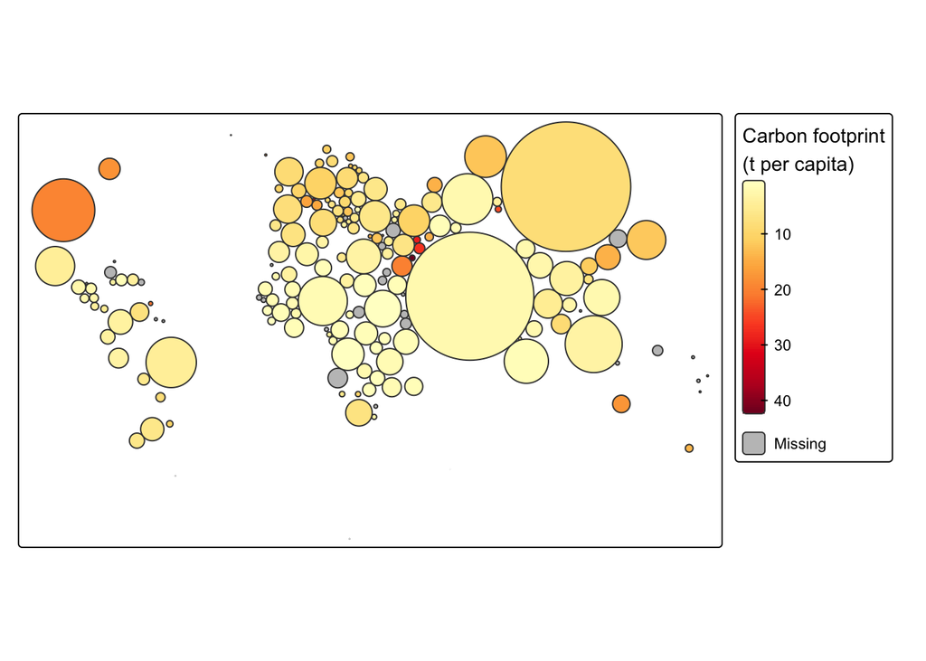

```r
tm_shape(World, crs = "+proj=robin") +
  tm_cartogram_dorling(
    size = "pop_est",
    fill = "footprint",
    fill.scale = tm_scale_continuous(values = "brewer.yl_or_rd"),
    fill.legend = tm_legend("Carbon footprint\n(t per capita)"))
```

> **Answer:** There is no single correct answer. Contiguous cartograms keep the neighbourhood relations, but shapes are distorted; non-contiguous cartograms keep the shapes, but small countries become tiny; Dorling cartograms are the most abstract, but each country is easy to compare by size.